# The Impact of Mobile Phone Features on Pricing: A Statistical Approach

Ang Jia Yi

2024-07-10

# Topic Overview

In the rapidly evolving mobile phone market, it is crucial for companies to develop competitive and well-priced products to capture different market segments. It is found that the mobile phone price and product features will influence the consumers’ purchasing intention. Geçit and Kayacan (2017) found that mobile phone price has a negative effect on the consumers’ mobile phone purchase decision, which as the price increases, the intention of consumers to purchase the mobile phone decreases. Besides, Manandhar and Timilsina (2023) stated that the mobile phone features significantly impact the purchasing decisions of consumers, where they further suggested mobile phones companies to conduct market research to determine the features demanded by the consumers such as camera resolution, a stylish and lighter design, or any innovative software and hardware advancement to boost sales. However, the pricing of a mobile phone is also often influenced by the features it possesses. Hence, a balance is needed to be achieved between the features associated with a mobile phone and its price, so that consumers have higher intention to purchase it.

To achieve this, predictive modelling can be a valuable tool. By analysing historical data on mobile phone features and their corresponding prices, we can identify which variables most significantly influence pricing. This analysis will help us establish an effective pricing model that optimally reflects the attributes of each market segment. Key features to consider include weight, thickness, battery capacity, screen size, pixels per inch (PPI), rear camera, front camera, number of CPU cores, CPU frequency, internal memory, and RAM.

The objective of this project is to develop predictive models using various combinations of these features to determine the optimal set of variables that best predict mobile phone prices. The insights gained will guide the pricing strategy for the new mobile phone series, ensuring that each model is competitively priced and aligned with market expectations.

# Problem

## Scenario

As the head of the product development team at a leading mobile phone company, you are tasked with launching a new series of mobile phones. This series will include models targeting different market segments: budget, mid-range, and premium. After some research, it is found that apart from mobile phone price, the product features will also influence the purchasing decision of consumers (Geçit & Kayacan, 2017; Manandhar & Timilsina, 2023). Therefore, to optimize the pricing strategy, you need to consider various factors that influence the cost and perceived value of the mobile phones. These factors include weight, thickness, battery capacity, screen size, pixels per inch (PPI), rear camera, front camera, number of CPU cores, CPU frequency, internal memory, and RAM.

## Problem Statement

Develop predictive models using various combinations of features (including weight, thickness, battery capacity, screen size, camera specifications, CPU performance, internal memory, and RAM) to identify which variables have the most significant influence on mobile phone pricing. The objective is to determine the optimal combination of features that best predicts prices and to establish the most effective pricing model for the new mobile phone series across budget, mid-range, and premium segments.

# Data

The dataset used for this analysis is a mobile price prediction dataset, sourced from Kaggle (Younesi, 2022). This dataset includes a comprehensive set of features related to mobile phone specifications and their corresponding prices. The mobile phone specifications include weight, thickness, battery capacity, screen resolution, PPI, rear camera, front camera, CPU cores, CPU frequency, internal memory, and RAM. This makes the dataset an ideal resource for developing predictive pricing models. The variable “Sale” has been excluded during data extraction, as we are investigating the impact of mobile phone features on its price.

During the initial data extraction, we encountered a variable labeled “type of CPU cores” However, the data for this variable consisted of numerical values ranging from 0 to 8. Upon closer examination, it became evident that these numbers more accurately represented the number of CPU cores in each mobile phone rather than different types of CPU cores.

To ensure the integrity and usability of our dataset, we decided to treat this variable as representing the number of CPU cores. Consequently, the variable was renamed to “number of CPU cores” to reflect its true nature. Additionally, any entries with a value of 0 for the number of CPU cores were treated as missing data. These entries were subsequently removed from the dataset to avoid any inaccuracies or potential biases in our analysis. This preprocessing step was crucial to ensure that the dataset accurately represents the specifications of the mobile phones under study.

Furthermore, during our analysis on the data found, we found that the data for the resolution is represented by a single number. For example, 4, 4.7 and 5.5, which is actually describing the screen size of the mobile phone in inches rather than the the resolution of the mobile phone, which should be represented by two numbers, for example, 1920 x 1080 pixels and 2560 x 1440 pixels. Hence, we decide to amend the variable name from resolution to screen size.

## Data Description

### Weight

Weight is the total mass of a mobile phone, which is significant for comfort and long-term usage, with a balance between durability and convenience. The weight often correlates with other factors that contribute to a mobile phone’s cost. For instance, research indicates that features like a larger battery or more robust materials, which contribute to a phone’s weight, can also increase its price due to their added value and production costs (Mustafa & Al-Rifat, 2019). Hence, the new mobile phones’ features should be built within a certain weight that does not burden the daily usage of consumers. This could potentially influence the production costs and the final price of the mobile phones launched.

### Thickness

The thickness of a mobile phone can determine whether its appearance is aesthetically and in line with consumers’ perception. Octaviani and Rahmawan (2023) found that customer buying interest in iPhone Mini is positively and significantly influenced by product design. However, usually the mobile phone price increases as its thickness decreases. This is due the increase in production costs as it requires more advanced engineering and design to maintain the phone performance and durability while minimising bulk. The research made by Elsheikh et al. (2023) has highlighted that the effort to balance thinness with functionality and battery life necessitates costlier, compact components and materials, leading to higher prices. Hence, an optimal thickness of the mobile phone is needed to balance between its price and performance.

### Battery

Mobile phone batteries with higher capacity will have longer battery life, which is a driving factor of higher mobile phone price. Negi and Pandey (2013) discovered that the longest battery backup is the most important consideration for young females in Bangladesh when purchasing mobile phones. Besides, batteries with advanced technology features such as fast charging and wireless charging are also more costly. Shalahb Gaur (2019) found that wireless charging technology that is energy conversion efficient is costlier. Hence, a battery with better quality can increase the phone’s performance and longevity, contributing to higher costs. Therefore, the battery brand and technology used would also influence the price of the new mobile phones.

### CPU Frequency (CPU_freq)

CPU frequency, measured in gigahertz (GHz), significantly impacts the speed at which a device processes data. Higher clock speeds mean that the processor can execute tasks more rapidly, enhancing everything from simple phone functions to complex application performance. Intel (n.d.) notes that within the same CPU generation, processors with greater clock speeds usually perform better than those with lower speeds in various tasks. As a result, mobile phones with higher CPU frequencies often deliver superior performance, which typically leads to higher market prices.

### Internal memory (InternalMem)

Internal memory is a key factor in enhancing a mobile phone’s usability. With more internal storage, a device can accommodate more applications and store greater amounts of data, which helps maintain the phone’s performance over time. As a result, mobile phones with larger storage capacities are perceived as more versatile and powerful, justifying higher price tags. This is particularly relevant as the size requirements for media files and apps grow. For instance, the base model of the iPhone 13 with 128GB is priced at $799, but upgrading to 256GB costs an additional $100, while a jump to 512GB adds another $400 to the price. Thus, fully upgrading the storage capacity can nearly double the cost of the iPhone 13 (Bowe, 2021). Clearly, internal storage is not just a component—it’s a significant investment that reflects and enhances a mobile phone’s market value.

### RAM

RAM (Random Access Memory) is a crucial element influencing mobile phone pricing. Increased RAM capacity enables smoother operation of multiple apps at once, essential for high-end gaming and professional applications that demand significant memory. As a result, phones with greater RAM can handle more tasks efficiently, leading to higher pricing due to improved multitasking performance and speed. While the presence of more RAM does raise the manufacturing cost of a mobile phone, it is considered a standard component. However, it’s important to note that other hardware components often play a more direct role in determining the final price of the phone (ScientiaMobile, 2022).

### Number of CPU cores (CPU_core)

The number of CPU cores is a pivotal factor in determining the multitasking capabilities and overall performance of a mobile phone. Having more cores allows a phone to process multiple tasks simultaneously, enhancing performance in applications that require multi-threading and improving overall efficiency in power usage. Essentially, the number of cores in a CPU signifies the device’s ability to handle concurrent tasks; thus, phones equipped with more cores typically offer superior multitasking capabilities (Lebara, 2024). This increased capacity for multitasking not only boosts the phone’s usability and responsiveness but also contributes to higher energy efficiency. As a result, mobile phones with greater core counts command higher prices in the market due to their enhanced performance and advanced capabilities.

### Screen Size (ScreenSize)

The screen size of a mobile phone is measured across the screen, from one corner to the opposite corner, and defined in inches. It is important for business users who frequently need to view two apps at once on their phone while multitasking with the multiple window feature (Arnold, 2017). The screen size will affect the cost of producing a mobile phone (Pakalka & Noreika, n.d.). The higher cost will lead to a higher price. Thus, the screen size is the factor that affects the final price of a mobile phone.

### Pixels Per Inch (PPI)

Pixels per inch (PPI) is calculated by dividing the diagonal resolution of the screen (in pixels) by the diagonal size of the screen (in inches). The screen of a mobile phone with a higher PPI will display images that are sharper and more detailed. However, it will cost more and require longer battery life for a mobile phone’s screen with a higher PPI (FasterCapital, 2024). Hence, PPI will affect the final price of a mobile phone.

### Rear Camera (RearCam)

Mobile phone technology has advanced far more quickly than that of most “proper” cameras because of the substantially larger research and development expenditures that are made by technology companies like Samsung and Apple (Dawood, 2018). Hence, with the larger capital invested in R&D to develop the rear camera, the price of the mobile phone will increase along with the development of the camera, and it also implies that the development of the number of Megapixels (MP) (resolution of a digital image or camera sensor) of the mobile phone will influence the final price of the mobile phone.

### Front Camera (FrontCam)

The primary uses of the front camera are “selfies”, facial recognition and iris scanning for devices (Everphone, n.d.). According to NEC (2022), the iPhone 13 was the most expensive mobile phone in 2022 due to Apple’s introduction of facial recognition technology. The front camera with higher Megapixels (MP) will indirectly improve face recognition performance. Hence, the improvement in the MP of the front camera will affect the price of the mobile phone.

# Extract and Examine the data

```r
# Read dataset
data_phone <- read.csv("C:/Users/User/Desktop/SUNWAY/Y3S2 REGRESSION ANALYSIS/Cellphone.csv", header=TRUE)

# Look at the structure of the variables
str(data_phone)
```

```
## 'data.frame':    151 obs. of  12 variables:
##  $ Price      : int  2357 1749 1916 1315 1749 2137 1238 2137 1315 2580 ...
##  $ Weight     : num  135 125 110 118 125 ...
##  $ ScreenSize : num  5.2 4 4.7 4 4 5.5 4 5.5 4 5.1 ...
##  $ PPI        : int  424 233 312 233 233 401 233 401 233 432 ...
##  $ CPU_core   : int  8 2 4 2 2 4 2 4 2 4 ...
##  $ CPU_freq   : num  1.35 1.3 1.2 1.3 1.3 2.3 1.2 2.3 1.3 2.5 ...
##  $ InternalMem: int  16 4 8 4 4 16 8 16 4 16 ...
##  $ RAM        : num  3 1 1.5 0.512 1 2 1 2 0.512 2 ...
##  $ RearCam    : num  13 3.15 13 3.15 3.15 16 2 16 3.15 16 ...
##  $ FrontCam   : num  8 0 5 0 0 8 0 8 0 2 ...
##  $ Battery    : int  2610 1700 2000 1400 1700 2500 1560 2500 1400 2800 ...
##  $ Thickness  : num  7.4 9.9 7.6 11 9.9 9.5 11.7 9.5 11 8.1 ...
```

```r
# View the summary of the dataset
summary(data_phone)
```

```
##      Price          Weight        ScreenSize          PPI
##  Min.   : 791   Min.   : 66.0   Min.   : 1.500   Min.   :121.0
##  1st Qu.:1794   1st Qu.:141.5   1st Qu.: 5.000   1st Qu.:235.0
##  Median :2323   Median :154.0   Median : 5.200   Median :306.0
##  Mean   :2316   Mean   :175.9   Mean   : 5.415   Mean   :347.7
##  3rd Qu.:2746   3rd Qu.:172.5   3rd Qu.: 5.500   3rd Qu.:432.0
##  Max.   :4361   Max.   :753.0   Max.   :12.200   Max.   :806.0
##     CPU_core        CPU_freq      InternalMem          RAM
##  Min.   :1.000   Min.   :0.208   Min.   :  0.00   Min.   :0.000
##  1st Qu.:4.000   1st Qu.:1.200   1st Qu.:  8.00   1st Qu.:1.000
##  Median :4.000   Median :1.500   Median : 16.00   Median :2.000
##  Mean   :5.179   Mean   :1.602   Mean   : 26.12   Mean   :2.349
##  3rd Qu.:8.000   3rd Qu.:1.875   3rd Qu.: 32.00   3rd Qu.:3.000
##  Max.   :8.000   Max.   :2.700   Max.   :128.00   Max.   :6.000
##     RearCam         FrontCam         Battery       Thickness
##  Min.   : 0.00   Min.   : 0.000   Min.   : 800   Min.   : 5.100
##  1st Qu.: 5.00   1st Qu.: 1.200   1st Qu.:2200   1st Qu.: 7.600
##  Median :12.00   Median : 5.000   Median :2820   Median : 8.400
##  Mean   :11.02   Mean   : 4.801   Mean   :2969   Mean   : 8.539
##  3rd Qu.:16.00   3rd Qu.: 8.000   3rd Qu.:3375   3rd Qu.: 9.350
##  Max.   :23.00   Max.   :20.000   Max.   :9500   Max.   :13.200
```

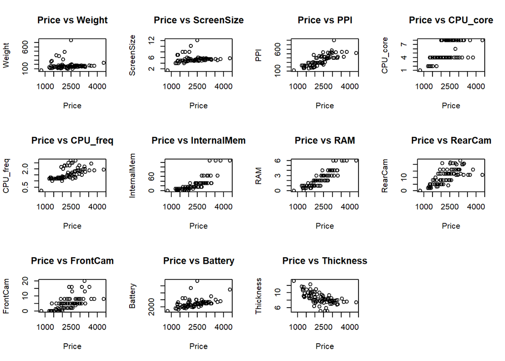

```r
price <- data_phone$Price
variables <- names(data_phone)[-1]  # Excluding the "Price" column

# Set up the plotting area
par(mfrow = c(3, 4))  # Adjust the number of rows and columns as needed

# Loop through each variable and plot against Price
for (variable in variables) {
  plot(price, data_phone[[variable]], main = paste("Price vs", variable),
       xlab = "Price", ylab = variable)
}

# Reset the plotting area to default
par(mfrow = c(1, 1))
```

## Scatter plot analysis

- **Price vs Screen Size and Price vs Weight:** There is no discernible trend, suggesting that the weight of a phone and the screen size does not have a significant impact on its price.
- **Price vs PPI:** The plot displays a positive trend, indicating that higher pixel density could contribute to higher prices, reflecting consumer preferences for better display quality.
- **Price vs CPU Core and Price vs CPU Frequency:** The plots show that higher numbers of CPU cores and higher CPU frequencies tend to be associated with higher-priced phones, emphasizing the value placed on processing power.
- **Price vs Internal Memory and Price vs RAM:** Both attributes show a positive relationship with price, which means phones with more memory and RAM are generally priced higher, likely due to better performance capabilities.
- **Price vs Rear Camera and Price vs Front Camera:** The plots show some level of positive relationship, especially with higher specifications of rear cameras, suggesting that better camera quality may influence the price, though the relationship is not as strong as it is with internal memory or CPU specs.
- **Price vs Battery:** There’s a slight positive relationship, indicating that phones with larger battery capacities tend to have higher prices, likely due to the longer usage they offer.
- **Price vs Thickness:** This plot reveals a moderate negative trend, suggesting a possible consumer preference for thinner devices, which might be associated with higher prices.

The scatter plots collectively examine the relationship between various technical specifications of mobile phones and their market prices. Generally, performance-related specifications such as **CPU frequency, internal memory, and RAM** show a clear positive correlation with price, suggesting that higher performance metrics are associated with higher-priced models, reflecting consumer demand for more powerful devices. Similarly, features that enhance user experience, namely **battery capacity**, also tend to increase with price, indicating a market preference for longer battery life. Interestingly, **camera specifications, both rear and front**, show a more moderate impact on pricing, suggesting that while important, they may not be the primary driver of price differences. Conversely, the **thickness** of phones shows a moderate negative relationship with price, hinting at a premium on sleeker, thinner designs. Overall, these plots underscore the multifaceted factors that contribute to the pricing of mobile devices, with a strong emphasis on performance and user experience enhancements.

# Correlation Matrix

```r
# Calculate the correlation matrix for the data_phone dataset and round the values to 4 decimal places
rounded_correlation_matrix <- round(cor(data_phone), 4)
rounded_correlation_matrix
```

```
##               Price  Weight ScreenSize     PPI CPU_core CPU_freq InternalMem
## Price        1.0000  0.0338     0.1850  0.7877   0.5770   0.6079      0.7920
## Weight       0.0338  1.0000     0.9329 -0.1528   0.1180   0.1001      0.0512
## ScreenSize   0.1850  0.9329     1.0000 -0.0173   0.2768   0.2536      0.1053
## PPI          0.7877 -0.1528    -0.0173  1.0000   0.3758   0.6714      0.5934
## CPU_core     0.5770  0.1180     0.2768  0.3758   1.0000   0.2439      0.1958
## CPU_freq     0.6079  0.1001     0.2536  0.6714   0.2439   1.0000      0.4029
## InternalMem  0.7920  0.0512     0.1053  0.5934   0.1958   0.4029      1.0000
## RAM          0.8922  0.0759     0.1806  0.7128   0.3786   0.5713      0.8737
## RearCam      0.6787 -0.1397     0.0454  0.7372   0.5142   0.5206      0.4074
## FrontCam     0.6500 -0.0720     0.0751  0.4390   0.5433   0.2520      0.5288
## Battery      0.4679  0.8283     0.8252  0.1953   0.3420   0.3355      0.4203
## Thickness   -0.6194 -0.0551    -0.2967 -0.3759  -0.5902  -0.3320     -0.3254
##                 RAM RearCam FrontCam Battery Thickness
## Price        0.8922  0.6787   0.6500  0.4679   -0.6194
## Weight       0.0759 -0.1397  -0.0720  0.8283   -0.0551
## ScreenSize   0.1806  0.0454   0.0751  0.8252   -0.2967
## PPI          0.7128  0.7372   0.4390  0.1953   -0.3759
## CPU_core     0.3786  0.5142   0.5433  0.3420   -0.5902
## CPU_freq     0.5713  0.5206   0.2520  0.3355   -0.3320
## InternalMem  0.8737  0.4074   0.5288  0.4203   -0.3254
## RAM          1.0000  0.5918   0.6137  0.4748   -0.4431
## RearCam      0.5918  1.0000   0.5542  0.1651   -0.4469
## FrontCam     0.6137  0.5542   1.0000  0.2207   -0.4693
## Battery      0.4748  0.1651   0.2207  1.0000   -0.2583
## Thickness   -0.4431 -0.4469  -0.4693 -0.2583    1.0000
```

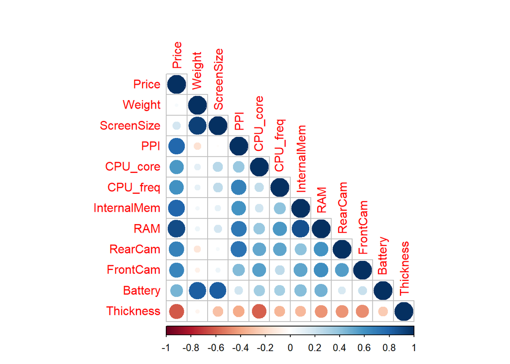

```r
# Plot the correlation matrix using the corrplot package, displaying only the lower triangular part of the matrix
corrplot::corrplot(rounded_correlation_matrix, type = 'lower')
```

## Interpretation

**Very Strong Positive Correlation:**

- **RAM and Price (0.8922):** A very strong positive correlation exists between RAM and price, demonstrating that higher RAM significantly increases mobile phone prices. This correlation is the strongest among all the predictors, indicating RAM as a crucial pricing factor.

**Strong Positive Correlation:**

- **Internal Memory and Price (0.7920):** A strong positive correlation suggests that mobile phones with larger internal memory command higher prices, emphasizing the importance of storage capacity in price determination.
- **PPI and Price (0.7877):** A strong positive correlation indicates that higher PPI, enhancing screen sharpness, tends to increase the mobile phone’s price significantly.
- **Rear Camera and Price (0.6787):** A strong positive correlation between rear camera quality and price reflects consumer demand for high-quality photography capabilities.
- **Front Camera and Price (0.6500):** Strong positive correlation shows that superior front camera quality, crucial for selfies and video calls, can drive up mobile phone prices.

**Moderate Positive Correlation:**

- **CPU Frequency and Price (0.6079):** Higher CPU frequencies, enhancing processing speed, correlate moderately with higher mobile phone prices.
- **CPU Core and Price (0.5770):** The number of CPU cores, which facilitates multitasking, shows a moderate positive correlation with price.
- **Battery and Price (0.4679):** Larger battery capacities, offering extended usage, are moderately associated with higher prices.

**Weak Positive Correlation:**

- **Screen Size and Price (0.1850):** A weak positive correlation indicates that larger screen sizes may slightly influence the price, though they are not a primary price determinant.

**Very Weak Positive Correlation**

- **Weight and Price (0.0338):** A negligible positive correlation suggests that weight has minimal impact on the price of mobile phones.

**Negative Correlation:**

- **Thickness and Price (-0.6194):** A strong negative correlation shows that thinner mobile phones are generally more expensive, reflecting the higher costs associated with their design and production.

# Fit the model

## Full Model

```r
# Fit a linear regression model to predict Price using all variables in data_phone
full_model <- lm(Price ~ ., data = data_phone)

# Display a summary of the full_model
summary(full_model)
```

```
##
## Call:
## lm(formula = Price ~ ., data = data_phone)
##
## Residuals:
##     Min      1Q  Median      3Q     Max
## -388.82 -121.26  -10.75  133.69  457.31
##
## Coefficients:
##               Estimate Std. Error t value Pr(>|t|)
## (Intercept) 2012.13570  241.37916   8.336 6.69e-14 ***
## Weight        -0.36715    0.72284  -0.508 0.612306
## ScreenSize   -98.82041   46.18458  -2.140 0.034127 *
## PPI            1.09355    0.22172   4.932 2.29e-06 ***
## CPU_core      50.21902   10.11851   4.963 2.00e-06 ***
## CPU_freq     122.95185   47.76144   2.574 0.011091 *
## InternalMem    5.10580    1.14999   4.440 1.82e-05 ***
## RAM           97.61037   25.81082   3.782 0.000231 ***
## RearCam        2.29580    4.26227   0.539 0.591002
## FrontCam       6.23121    5.03362   1.238 0.217834
## Battery        0.14583    0.03038   4.801 4.03e-06 ***
## Thickness    -91.95386   14.37470  -6.397 2.25e-09 ***
## ---
## Signif. codes:  0 '***' 0.001 '**' 0.01 '*' 0.05 '.' 0.1 ' ' 1
##
## Residual standard error: 173.7 on 139 degrees of freedom
## Multiple R-squared:  0.9401, Adjusted R-squared:  0.9354
## F-statistic: 198.5 on 11 and 139 DF,  p-value: < 2.2e-16
```

**Model Performance:**

- **Residual standard error:** 173.7 on 139 degrees of freedom
- **Multiple R-squared:** 0.9401
  - Indicates that 94.01% of the variance in price is explained by the model.
- **Adjusted R-squared:** 0.9354
  - Adjusted for the number of predictors, still indicating a very good fit.
- **F-statistic:** 198.5 on 11 and 139 DF, p < 2.2e-16
  - Overall model is highly significant.

**Significance Summary:**

We can observe the significance of each coefficients from the summary above:

- **Significant Positive Predictors:** PPI, CPU Core, CPU Frequency, Internal Memory, RAM, Battery
- **Significant Negative Predictors:** Screen Size, Thickness
- **Non-significant Predictors:** Weight, Rear Camera, Front Camera

These results suggest that higher PPI, more CPU cores, higher CPU frequency, more internal memory, more RAM, and larger battery capacity are associated with higher mobile phone prices. In contrast, larger screen size and greater thickness are associated with lower prices. Weight, rear camera, and front camera do not have significant effects on the price.

**Conclusion:**

The analysis demonstrates that multiple factors, including PPI, CPU core count, CPU frequency, internal memory, RAM, and battery capacity, strongly influence mobile phone prices. The significant F-statistic and a high R-squared value (0.9401) confirm that these predictors collectively offer a reliable basis for forecasting mobile phone prices. This model effectively explains 94.01% of the variability in price, underscoring the importance of processing power, memory capacity, and battery life in determining phone costs. However, to account for the remaining 6% of variability in price, further analysis might explore additional variables or external market factors.

## Fit some smaller models

### Model 1

This model investigates the relationship between the Price of a mobile phone and its RAM.

```r
# Fit a linear regression model to predict Price using RAM as the predictor
model1 <- lm(Price ~ RAM, data = data_phone)

# Display a summary of the model1
summary(model1)
```

```
##
## Call:
## lm(formula = Price ~ RAM, data = data_phone)
##
## Residuals:
##     Min      1Q  Median      3Q     Max
## -689.07 -178.09  -46.85  176.87  745.66
##
## Coefficients:
##             Estimate Std. Error t value Pr(>|t|)
## (Intercept)  1396.61      45.69   30.57   <2e-16 ***
## RAM           391.24      16.23   24.11   <2e-16 ***
## ---
## Signif. codes:  0 '***' 0.001 '**' 0.01 '*' 0.05 '.' 0.1 ' ' 1
##
## Residual standard error: 309.8 on 149 degrees of freedom
## Multiple R-squared:  0.796,  Adjusted R-squared:  0.7946
## F-statistic: 581.4 on 1 and 149 DF,  p-value: < 2.2e-16
```

**Coefficients:**

- **Intercept (1396.61):** This is the estimated price when RAM is zero, highly significant (p < 0.001). This value is the baseline price without considering the RAM effect.
- **RAM (391.24):** This coefficient represents the expected change in price for each additional unit of RAM. It indicates a highly significant (p < 0.001) positive relationship between RAM and price. Specifically, for each 1 GB increase in RAM, the price is expected to increase by approximately 391.24 units.

**Model Performance:**

- **Residual standard error:** 309.8 on 149 degrees of freedom
  - This error term indicates the average difference between the observed values and the model’s predictions, suggesting moderate variability around the predicted values.
- **Multiple R-squared:** 0.796
  - This statistic means that approximately 79.6% of the variability in mobile phone price is explained by the RAM alone, which is a strong fit for such a simple model.
- **Adjusted R-squared:** 0.7946
  - Adjusting for the number of predictors, the model still explains roughly 79.46% of the variance, reinforcing the effectiveness of RAM in predicting price.
- **F-statistic:** 581.4 on 1 and 149 degrees of freedom, with a p-value < 2.2e-16
  - This highly significant F-statistic indicates that the model is statistically significant, meaning RAM is a crucial predictor of mobile phone price.

**Conclusion:**

The analysis shows a strong positive relationship between the amount of RAM in a mobile phone and its price. The significant F-statistic and high R-squared value confirm that RAM is an excellent predictor of price in this dataset. This model is reliable for predicting mobile phone prices based on RAM but may benefit from considering other variables to account for the remaining 20% of variability in price.

### Model 2

This model investigates the relationship between the price of a mobile phone and its thickness.

```r
# Fit a linear regression model to predict Price using Thickness as the predictor
model2 <- lm(Price ~ Thickness, data = data_phone)

# Display a summary of model2
summary(model2)
```

```
##
## Call:
## lm(formula = Price ~ Thickness, data = data_phone)
##
## Residuals:
##     Min      1Q  Median      3Q     Max
## -946.12 -421.41  -48.84  363.59 1736.31
##
## Coefficients:
##             Estimate Std. Error t value Pr(>|t|)
## (Intercept)  4633.25     244.64   18.94   <2e-16 ***
## Thickness    -271.43      28.19   -9.63   <2e-16 ***
## ---
## Signif. codes:  0 '***' 0.001 '**' 0.01 '*' 0.05 '.' 0.1 ' ' 1
##
## Residual standard error: 538.4 on 149 degrees of freedom
## Multiple R-squared:  0.3836, Adjusted R-squared:  0.3795
## F-statistic: 92.73 on 1 and 149 DF,  p-value: < 2.2e-16
```

**Coefficients:**

- **Intercept (4633.25):** This is the estimated price when thickness is zero, highly significant (p < 0.001). This value serves as the baseline price assuming the absence of the thickness variable.
- **Thickness (-271.43):** This coefficient represents the expected change in price for each one-unit increase in thickness. The negative value (-271.43) is highly significant (p < 0.001), indicating that an increase in thickness tends to decrease the mobile phone’s price. This matches the intuitive notion that sleeker (thinner) phones might be priced higher due to consumer preferences or manufacturing costs.

**Model Performance:**

- **Residual standard error:** 538.4 on 149 degrees of freedom
  - This error term reflects the average deviation of the observed prices from the predicted values, indicating a somewhat high variability.
- **Multiple R-squared:** 0.3836
  - This value suggests that approximately 38.36% of the variability in mobile phone price is explained by the thickness alone. This indicates a moderate explanatory power of the model.
- **Adjusted R-squared:** 0.3795
  - This adjusted metric accounts for the number of predictors (one in this case) and suggests a similar explanatory power after adjustment.
- **F-statistic:** 92.73 on 1 and 149 degrees of freedom, with a p-value < 2.2e-16
  - The highly significant F-statistic confirms that the model is statistically significant, indicating that thickness is a crucial factor affecting the price of mobile phones, albeit not the only one given the R-squared value.

**Conclusion:**

The analysis shows a strong negative relationship between the thickness of a mobile phone and its price, with thinner phones generally commanding higher prices. While the model’s fit is moderate, indicating that other factors also play significant roles in pricing, thickness alone has a clear and statistically significant impact on price.

### Model 3

This model includes both RAM and thickness as predictors for Price.

```r
# Fit a linear regression model to predict Price using RAM and Thickness as predictors
model3 <- lm(Price ~ RAM + Thickness, data = data_phone)

# Display a summary of model3
summary(model3)
```

```
##
## Call:
## lm(formula = Price ~ RAM + Thickness, data = data_phone)
##
## Residuals:
##     Min      1Q  Median      3Q     Max
## -630.45 -164.28  -12.28  174.10  675.55
##
## Coefficients:
##             Estimate Std. Error t value Pr(>|t|)
## (Intercept)  2567.08     149.78  17.139  < 2e-16 ***
## RAM           337.08      15.13  22.283  < 2e-16 ***
## Thickness    -122.17      15.12  -8.082 2.08e-13 ***
## ---
## Signif. codes:  0 '***' 0.001 '**' 0.01 '*' 0.05 '.' 0.1 ' ' 1
##
## Residual standard error: 258.9 on 148 degrees of freedom
## Multiple R-squared:  0.8585, Adjusted R-squared:  0.8566
## F-statistic: 448.8 on 2 and 148 DF,  p-value: < 2.2e-16
```

**Coefficients:**

- **Intercept (2567.08):** This is the baseline price when both RAM and thickness are zero. It is highly significant (p < 0.001), suggesting a strong baseline influence on price.
- **RAM (337.08):** The coefficient for RAM is highly significant (p < 0.001) and positive, indicating that each unit increase in RAM (likely measured in GB) is associated with an increase in price by about 337.08 units. This result corroborates the known influence of RAM on enhancing device performance and consequently its price.
- **Thickness (-122.17):** The coefficient for thickness is also highly significant (p < 0.001) but negative, indicating that each unit increase in thickness is associated with a decrease in price by about 122.17 units. This may reflect market preferences for thinner devices, which are often considered more modern and portable.

**Model Performance:**

- **Residual standard error:** 258.9 on 148 degrees of freedom
  - Indicates the average deviation of the observed prices from those predicted by the model, suggesting moderate variability around the predicted values.
- **Multiple R-squared:** 0.8585
  - This statistic means that approximately 85.85% of the variability in mobile phone price is explained by the model, which is quite high, indicating a strong fit.
- **Adjusted R-squared:** 0.8566
  - Adjusting for the number of predictors (two in this case), the model still explains about 85.66% of the variance, reinforcing the effectiveness of RAM and thickness in predicting price.
- **F-statistic:** 448.8 on 2 and 148 degrees of freedom, with a p-value < 2.2e-16
  - This highly significant F-statistic indicates that the model overall is statistically significant, meaning both RAM and thickness are crucial predictors of mobile phone price.

**Conclusion:**

Model 3 demonstrates a strong ability to predict mobile phone prices based on RAM and thickness. The positive effect of RAM and the negative effect of thickness are both statistically significant and substantial. The high R-squared values suggest that including these two predictors provides a robust model for explaining price variability, although some outliers and extreme values indicate potential limits to the model’s applicability across all observations.

## Calculate VIF

VIF measures how much the variance of a regression coefficient is inflated due to multicollinearity with other predictors in the model. - **VIF = 1:** No multicollinearity (each predictor is not correlated with others). - **1 < VIF < 5:** Moderate multicollinearity (acceptable levels). - **VIF > 5:** High multicollinearity (problematic, requires attention). - **VIF > 10:** Very high multicollinearity (often considered unacceptable)

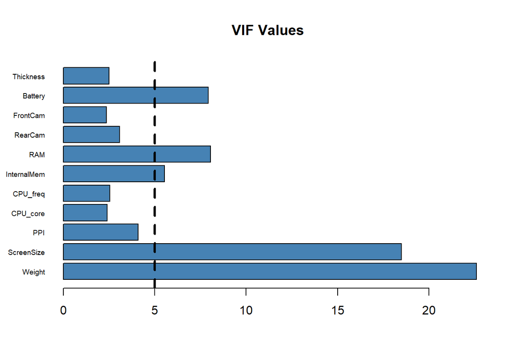

```r
# Calculate VIF values for the full_model
vif_values <- vif(full_model)

# Create a horizontal bar plot of VIF values
barplot(vif_values, main = "VIF Values", horiz = TRUE, col = "steelblue", las = 1, cex.names = 0.6)

# Add a vertical dashed line at VIF = 5
abline(v = 5, lwd = 3, lty = 2)
```

**Summary**

- **High Multicollinearity:**
  - **Weight** and **Screen Size** exhibit very high VIF values, which could seriously affect the reliability of the regression coefficients associated with these predictors.
- **Moderate Multicollinearity:**
  - **Battery, RAM**, and **Internal Memory** are above the VIF threshold of 5, suggesting these factors also contribute to multicollinearity, albeit not as severely as Weight and Resolution.
- **Low Multicollinearity:**
  - **Thickness, Front Camera, Rear Camera, CPU Frequency, CPU Core**, and **PPI** have VIF values below 5, indicating that multicollinearity is less of a concern for these variables.

### Model 4

From the VIF results above, we can thus derive a model.This model predicts price using all other variables in the dataset except for battery, RAM, internal memory, screen size, and weight due to their high VIF values.

```r
# Fit a linear regression model to predict Price according to the VIF approach
model4 <- lm(Price ~ . -Battery -RAM -InternalMem -ScreenSize -Weight, data = data_phone)

# Display a summary of model4
summary(model4)
```

```
##
## Call:
## lm(formula = Price ~ . - Battery - RAM - InternalMem - ScreenSize -
##     Weight, data = data_phone)
##
## Residuals:
##     Min      1Q  Median      3Q     Max
## -548.57 -161.41  -41.96  161.28 1192.49
##
## Coefficients:
##              Estimate Std. Error t value Pr(>|t|)
## (Intercept) 1613.6722   257.1016   6.276 3.84e-09 ***
## PPI            2.6575     0.3291   8.075 2.45e-13 ***
## CPU_core      35.7545    15.7566   2.269  0.02474 *
## CPU_freq     198.4878    72.1965   2.749  0.00674 **
## RearCam       -8.1869     7.0687  -1.158  0.24870
## FrontCam      42.1667     7.5516   5.584 1.14e-07 ***
## Thickness    -98.1022    20.7282  -4.733 5.24e-06 ***
## ---
## Signif. codes:  0 '***' 0.001 '**' 0.01 '*' 0.05 '.' 0.1 ' ' 1
##
## Residual standard error: 304.2 on 144 degrees of freedom
## Multiple R-squared:  0.8098, Adjusted R-squared:  0.8019
## F-statistic: 102.2 on 6 and 144 DF,  p-value: < 2.2e-16
```

**Model Performance:**

- **Residual Standard Error:** 304.2 on 144 degrees of freedom
  - Reflects the average size of the residuals.
- **Multiple R-squared:** 0.8098
  - Approximately 80.98% of the variability in phone price is explained by the model, which is quite high.
- **Adjusted R-squared:** 0.8019
  - Adjusts the R-squared for the number of predictors used, still indicating a strong model.
- **F-statistic:** 102.2 on 6 and 144 DF, with a p-value < 2.2e-16
  - The model is statistically significant, meaning the predictors collectively influence the phone price significantly.

**Significance Summary:**

We can observe the significance of each coefficients from the summary above:

- **Significant Positive Predictors:** PPI, CPU Core, CPU Frequency, Front Camera
- **Significant Negative Predictors:** Thickness
- **Non-significant Predictors:** Rear Camera

**Conclusion:**

This model effectively explains a substantial portion of the variability in phone prices based on several key features, despite excluding variables prone to multicollinearity. The significant predictors like PPI, CPU frequency, front camera, and thickness have clear associations with price, confirming their importance in determining mobile phone pricing. The model’s overall fit is robust, but careful attention might be needed for potential outliers or unusual data points suggested by the spread in residuals.

## Best Subset Selection using BIC

Best subset selection using BIC evaluates all possible combinations of predictors and selects the model that minimises the Bayesian Information Criterion (BIC), balancing fit and complexity. BIC penalises the inclusion of additional predictors to avoid overfitting, ensuring the selected model is both accurate and interpretable. This method identifies the most significant predictors, optimising the model’s explanatory power while maintaining simplicity.

```r
# Perform subset selection with up to 12 predictors and 2 best models for each subset size
subset_model <- regsubsets(Price ~ ., data = data_phone, nbest = 2, nvmax = 12)

# Display a summary of the subset selection results
summary(subset_model)
```

```
## Subset selection object
## Call: regsubsets.formula(Price ~ ., data = data_phone, nbest = 2, nvmax = 12)
## 11 Variables  (and intercept)
##             Forced in Forced out
## Weight          FALSE      FALSE
## ScreenSize      FALSE      FALSE
## PPI             FALSE      FALSE
## CPU_core        FALSE      FALSE
## CPU_freq        FALSE      FALSE
## InternalMem     FALSE      FALSE
## RAM             FALSE      FALSE
## RearCam         FALSE      FALSE
## FrontCam        FALSE      FALSE
## Battery         FALSE      FALSE
## Thickness       FALSE      FALSE
```

[output cut: 46 more lines]

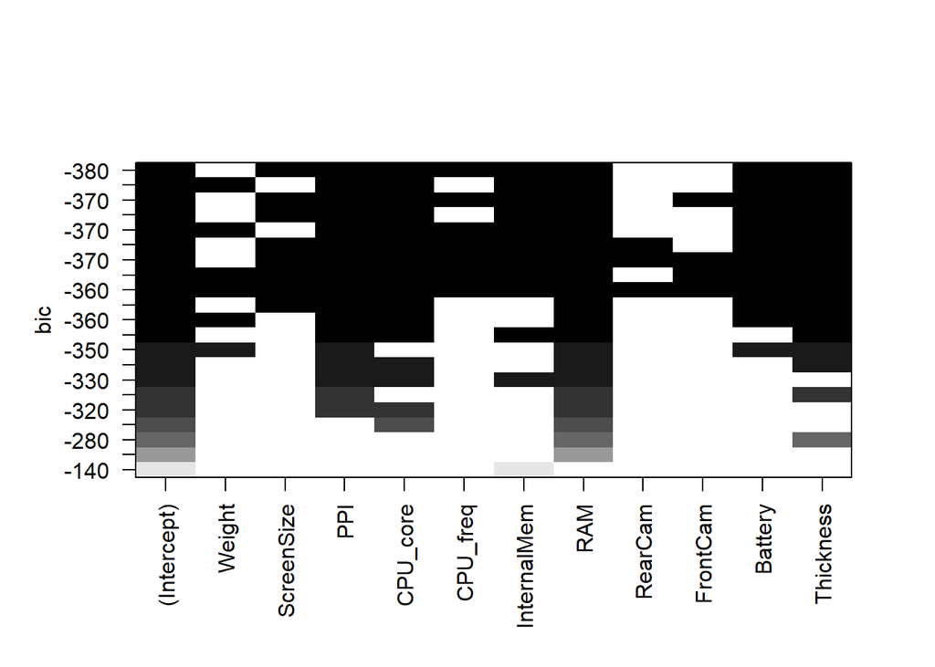

```r
# Plot the results of the subset selection
plot(subset_model)
```

**From the Chart:**

- **Shades of Gray:** The shades of gray indicate the BIC values, with darker shades representing lower (better) BIC values. Lighter shades represent higher BIC values, suggesting less optimal models according to the criterion.
- **Predictor Inclusion:** Each filled block in the chart indicates that the predictor (column) is included in the model (row). The absence of a block means the predictor is not included in that particular model.

The best subset selection chart using BIC provides a visual representation of the most effective combinations of predictors for different model sizes. By examining the chart, we can identify that the optimal model includes the predictors: PPI, CPU_core, CPU_freq, InternalMem, Ram, ScreenSize, Battery, and Thickness. This optimal model is indicated by the row with the lowest BIC value, suggesting it offers the best balance between model fit and complexity. Predictors like PPI and CPU_core appear consistently in the best models across different sizes, highlighting their significant role in predicting the price of mobile phones. The chart demonstrates that while adding more predictors generally improves the model up to a point, including too many predictors can lead to overfitting, as indicated by increasing BIC values. Therefore, the identified optimal model provides robust and interpretable predictions, balancing the need for accuracy with the simplicity of the model.

### Model 5

From the BIC results above, we can thus derive a model. This model predicts the price based on all available variables except for weight, rear camera, and front camera. These variables were likely excluded based on previous BIC results to optimise the model.

```r
# Fit a linear regression model to predict Price according to the results of the BIC approach
model5 <- lm(Price ~ . -Weight -RearCam -FrontCam, data = data_phone)

# Display a summary of model5
summary(model5)
```

```
##
## Call:
## lm(formula = Price ~ . - Weight - RearCam - FrontCam, data = data_phone)
##
## Residuals:
##     Min      1Q  Median      3Q     Max
## -388.40 -139.75   -0.42  118.99  447.40
##
## Coefficients:
##               Estimate Std. Error t value Pr(>|t|)
## (Intercept) 2095.87041  188.02239  11.147  < 2e-16 ***
## ScreenSize  -116.27635   23.89800  -4.866 3.00e-06 ***
## PPI            1.13864    0.19500   5.839 3.42e-08 ***
## CPU_core      57.70894    9.14589   6.310 3.34e-09 ***
## CPU_freq     123.86977   45.56624   2.718  0.00738 **
## InternalMem    5.19510    1.11795   4.647 7.61e-06 ***
## RAM          110.16155   24.61668   4.475 1.55e-05 ***
## Battery        0.13039    0.02591   5.032 1.44e-06 ***
## Thickness    -96.69199   12.77935  -7.566 4.41e-12 ***
## ---
## Signif. codes:  0 '***' 0.001 '**' 0.01 '*' 0.05 '.' 0.1 ' ' 1
##
## Residual standard error: 173.7 on 142 degrees of freedom
## Multiple R-squared:  0.9388, Adjusted R-squared:  0.9354
## F-statistic: 272.5 on 8 and 142 DF,  p-value: < 2.2e-16
```

**Model Performance:**

- **Residual standard error:** 173.7 on 142 degrees of freedom
  - Indicates variability around the fitted values, with a reasonably low error suggesting good model fit.
- **Multiple R-squared:** 0.9388
  - About 93.88% of the variability in phone prices is explained by this model, which is very high, showing excellent explanatory power.
- **Adjusted R-squared:** 0.9354
  - Adjusts the R-squared for the number of predictors, still indicating a strong fit.
- **F-statistic:** 272.5 on 8 and 142 DF, p-value: < 2.2e-16
  - The overall model fit is statistically significant, suggesting that the predictors collectively have a significant effect on phone prices.

**Significance Summary:**

We can observe the significance of each coefficients from the summary above:

- **Significant Positive Predictors:** PPI, CPU Core, CPU Frequency, Internal Memory, RAM, Battery
- **Significant Negative Predictors:** Screen Size, Thickness

**Conclusion:**

Model 5 effectively captures the relationship between various phone characteristics and their prices with a high degree of explanatory power. Key performance specifications like PPI, CPU specifications, RAM, and design aspects like thickness are significant drivers of price. This model, streamlined by BIC selection, focuses on the most impactful predictors without overfitting, providing valuable insights for strategic pricing and product development.

## Stepwise Regression Methods

Stepwise regression methods are statistical techniques used to select the most significant variables in a regression model which involve adding or removing predictors based on certain criteria in order to improve the model’s performance while avoiding overfitting. Before proceeding with the stepwise regression methods, let’s generalise the linear models (full model, model 1, model 2, model 3, model 4, model 5) first.

### Full Model

```r
# Fit a generalized linear model to predict Price using all variables in data_phone
fullmodel <- glm(Price ~ ., data = data_phone)

# Display a summary of the fullmodel
summary(fullmodel)
```

```
##
## Call:
## glm(formula = Price ~ ., data = data_phone)
##
## Coefficients:
##               Estimate Std. Error t value Pr(>|t|)
## (Intercept) 2012.13570  241.37916   8.336 6.69e-14 ***
## Weight        -0.36715    0.72284  -0.508 0.612306
## ScreenSize   -98.82041   46.18458  -2.140 0.034127 *
## PPI            1.09355    0.22172   4.932 2.29e-06 ***
## CPU_core      50.21902   10.11851   4.963 2.00e-06 ***
## CPU_freq     122.95185   47.76144   2.574 0.011091 *
## InternalMem    5.10580    1.14999   4.440 1.82e-05 ***
## RAM           97.61037   25.81082   3.782 0.000231 ***
## RearCam        2.29580    4.26227   0.539 0.591002
## FrontCam       6.23121    5.03362   1.238 0.217834
## Battery        0.14583    0.03038   4.801 4.03e-06 ***
## Thickness    -91.95386   14.37470  -6.397 2.25e-09 ***
## ---
## Signif. codes:  0 '***' 0.001 '**' 0.01 '*' 0.05 '.' 0.1 ' ' 1
##
## (Dispersion parameter for gaussian family taken to be 30178.64)
##
##     Null deviance: 70079632  on 150  degrees of freedom
## Residual deviance:  4194831  on 139  degrees of freedom
## AIC: 1999.6
##
## Number of Fisher Scoring iterations: 2
```

The full model, which is with all the predictors, has been generalised. The value of Akaike Information Criterion (AIC) is 1999.6. It is hard to say this is the best as comparison is needed to compute which model is with the lowest AIC. AIC is a measure used to determine the model’s quality where the goodness of fit and the number of parameters used are considered. Therefore, lower AIC values indicate a better model.

### Null Model

```r
# Fit a null model (intercept-only model) to predict Price
nullmodel <- glm(Price ~ 1, data = data_phone)

# Display a summary of the null model
summary(nullmodel)
```

```
##
## Call:
## glm(formula = Price ~ 1, data = data_phone)
##
## Coefficients:
##             Estimate Std. Error t value Pr(>|t|)
## (Intercept)  2315.52      55.62   41.63   <2e-16 ***
## ---
## Signif. codes:  0 '***' 0.001 '**' 0.01 '*' 0.05 '.' 0.1 ' ' 1
##
## (Dispersion parameter for gaussian family taken to be 467197.5)
##
##     Null deviance: 70079632  on 150  degrees of freedom
## Residual deviance: 70079632  on 150  degrees of freedom
## AIC: 2402.7
##
## Number of Fisher Scoring iterations: 2
```

The null model, which is with the intercept only, has been generalised. The value of AIC is 2402.7. This shows that the full model is a better model for now in terms of value of AIC.

### Model 1

```r
# Convert model1 to a generalized linear model
model_1 <- glm(model1)

# Display a summary of model_1
summary(model_1)
```

```
##
## Call:
## glm(formula = model1)
##
## Coefficients:
##             Estimate Std. Error t value Pr(>|t|)
## (Intercept)  1396.61      45.69   30.57   <2e-16 ***
## RAM           391.24      16.23   24.11   <2e-16 ***
## ---
## Signif. codes:  0 '***' 0.001 '**' 0.01 '*' 0.05 '.' 0.1 ' ' 1
##
## (Dispersion parameter for gaussian family taken to be 95946.63)
##
##     Null deviance: 70079632  on 150  degrees of freedom
## Residual deviance: 14296048  on 149  degrees of freedom
## AIC: 2164.7
##
## Number of Fisher Scoring iterations: 2
```

Model 1 has been generalised. The value of AIC is 2164.7. This shows that the full model is the best model for now in terms of value of AIC.

### Model 2

```r
# Convert model2 to a generalized linear model
model_2 <- glm(model2)

# Display a summary of model_2
summary(model_2)
```

```
##
## Call:
## glm(formula = model2)
##
## Coefficients:
##             Estimate Std. Error t value Pr(>|t|)
## (Intercept)  4633.25     244.64   18.94   <2e-16 ***
## Thickness    -271.43      28.19   -9.63   <2e-16 ***
## ---
## Signif. codes:  0 '***' 0.001 '**' 0.01 '*' 0.05 '.' 0.1 ' ' 1
##
## (Dispersion parameter for gaussian family taken to be 289909.3)
##
##     Null deviance: 70079632  on 150  degrees of freedom
## Residual deviance: 43196490  on 149  degrees of freedom
## AIC: 2331.7
##
## Number of Fisher Scoring iterations: 2
```

Model 2 has been generalised. The value of AIC is 2331.7. This shows that the full model still is the best for now in terms of value of AIC.

### Model 3

```r
# Convert model3 to a generalized linear model
model_3 <- glm(model3)

# Display a summary of model_3
summary(model_3)
```

```
##
## Call:
## glm(formula = model3)
##
## Coefficients:
##             Estimate Std. Error t value Pr(>|t|)
## (Intercept)  2567.08     149.78  17.139  < 2e-16 ***
## RAM           337.08      15.13  22.283  < 2e-16 ***
## Thickness    -122.17      15.12  -8.082 2.08e-13 ***
## ---
## Signif. codes:  0 '***' 0.001 '**' 0.01 '*' 0.05 '.' 0.1 ' ' 1
##
## (Dispersion parameter for gaussian family taken to be 67017.78)
##
##     Null deviance: 70079632  on 150  degrees of freedom
## Residual deviance:  9918631  on 148  degrees of freedom
## AIC: 2111.5
##
## Number of Fisher Scoring iterations: 2
```

Model 3 has been generalised. The value of AIC is 2111.5. This shows that the full model still is the best for now in terms of value of AIC.

### Model 4

```r
# Convert model4 to a generalized linear model
model_4 <- glm(model4)

# Display a summary of model_4
summary(model_4)
```

```
##
## Call:
## glm(formula = model4)
##
## Coefficients:
##              Estimate Std. Error t value Pr(>|t|)
## (Intercept) 1613.6722   257.1016   6.276 3.84e-09 ***
## PPI            2.6575     0.3291   8.075 2.45e-13 ***
## CPU_core      35.7545    15.7566   2.269  0.02474 *
## CPU_freq     198.4878    72.1965   2.749  0.00674 **
## RearCam       -8.1869     7.0687  -1.158  0.24870
## FrontCam      42.1667     7.5516   5.584 1.14e-07 ***
## Thickness    -98.1022    20.7282  -4.733 5.24e-06 ***
## ---
## Signif. codes:  0 '***' 0.001 '**' 0.01 '*' 0.05 '.' 0.1 ' ' 1
##
## (Dispersion parameter for gaussian family taken to be 92560.95)
##
##     Null deviance: 70079632  on 150  degrees of freedom
## Residual deviance: 13328776  on 144  degrees of freedom
## AIC: 2164.1
##
## Number of Fisher Scoring iterations: 2
```

Model 4 has been generalised. The value of AIC is 2164.1. This shows that the full model still is the best for now in terms of value of AIC.

### Model 5

```r
# Convert model5 to a generalized linear model
model_5 <- glm(model5)

# Display a summary of model_5
summary(model_5)
```

```
##
## Call:
## glm(formula = model5)
##
## Coefficients:
##               Estimate Std. Error t value Pr(>|t|)
## (Intercept) 2095.87041  188.02239  11.147  < 2e-16 ***
## ScreenSize  -116.27635   23.89800  -4.866 3.00e-06 ***
## PPI            1.13864    0.19500   5.839 3.42e-08 ***
## CPU_core      57.70894    9.14589   6.310 3.34e-09 ***
## CPU_freq     123.86977   45.56624   2.718  0.00738 **
## InternalMem    5.19510    1.11795   4.647 7.61e-06 ***
## RAM          110.16155   24.61668   4.475 1.55e-05 ***
## Battery        0.13039    0.02591   5.032 1.44e-06 ***
## Thickness    -96.69199   12.77935  -7.566 4.41e-12 ***
## ---
## Signif. codes:  0 '***' 0.001 '**' 0.01 '*' 0.05 '.' 0.1 ' ' 1
##
## (Dispersion parameter for gaussian family taken to be 30183.48)
##
##     Null deviance: 70079632  on 150  degrees of freedom
## Residual deviance:  4286054  on 142  degrees of freedom
## AIC: 1996.8
##
## Number of Fisher Scoring iterations: 2
```

Model 5 has been generalised. The value of AIC is 1996.8. This shows that the model is the best for now in terms of value of AIC.

### Perform stepwise regression model

This method combines forward and backward stepwise regression. It begins with an empty model (null model) and adds predictors one by one, similar to forward stepwise regression. After adding a predictor, the model checks if any of the included predictors can be removed without significantly affecting the model fit. This iterative process of adding and removing predictors continues until no further improvements can be made.

```r
# Perform stepwise model selection from nullmodel to fullmodel in both directions
model.step <- step(nullmodel, scope=list(lower = nullmodel,
                                         upper = fullmodel,
                                         direction = "both"))
```

```
## Start:  AIC=2402.75
## Price ~ 1
##
##               Df Deviance    AIC
## + RAM          1 14296048 2164.7
## + InternalMem  1 26123073 2255.7
## + PPI          1 26594776 2258.4
## + RearCam      1 37796848 2311.5
## + FrontCam     1 40471537 2321.8
## + Thickness    1 43196490 2331.7
## + CPU_freq     1 44180002 2335.1
## + CPU_core     1 46748547 2343.6
## + Battery      1 54734340 2367.4
## + ScreenSize   1 67680458 2399.5
## <none>           70079632 2402.8
## + Weight       1 69999414 2404.6
##
## Step:  AIC=2164.71
## Price ~ RAM
##
##               Df Deviance    AIC
## + CPU_core     1  9613471 2106.8
## + Thickness    1  9918631 2111.5
## + PPI          1 11015193 2127.3
## + RearCam      1 11846288 2138.3
## + FrontCam     1 13115614 2153.7
## + CPU_freq     1 13293182 2155.7
## <none>           14296048 2164.7
## + Battery      1 14118320 2164.8
## + Weight       1 14215149 2165.8
## + InternalMem  1 14249726 2166.2
## + ScreenSize   1 14254534 2166.3
## - RAM          1 70079632 2402.8
##
## Step:  AIC=2106.79
## Price ~ RAM + CPU_core
##
##               Df Deviance    AIC
## + PPI          1  7429407 2069.9
## + Thickness    1  8288937 2086.4
```

[output cut: 117 more lines]

```
##     Battery + ScreenSize + FrontCam
##
##               Df Deviance    AIC
## <none>            4215791 1996.3
## - FrontCam     1  4286054 1996.8
## + RearCam      1  4202617 1997.8
## + Weight       1  4203587 1997.9
## - CPU_freq     1  4462520 2002.9
## - RAM          1  4680370 2010.1
## - InternalMem  1  4808532 2014.2
## - ScreenSize   1  4951008 2018.6
## - CPU_core     1  5029423 2021.0
## - Battery      1  5034811 2021.1
## - PPI          1  5275300 2028.2
## - Thickness    1  5896800 2045.0
```

```r
# Display a summary of the selected model
summary(model.step)
```

```
##
## Call:
## glm(formula = Price ~ RAM + CPU_core + PPI + Thickness + InternalMem +
##     CPU_freq + Battery + ScreenSize + FrontCam, data = data_phone)
##
## Coefficients:
##               Estimate Std. Error t value Pr(>|t|)
## (Intercept) 2084.07017  187.29320  11.127  < 2e-16 ***
## RAM          100.02958   25.37633   3.942 0.000127 ***
## CPU_core      51.70015    9.91078   5.217 6.38e-07 ***
## PPI            1.15768    0.19448   5.953 1.99e-08 ***
## Thickness    -95.53670   12.74134  -7.498 6.57e-12 ***
## InternalMem    4.98988    1.12070   4.452 1.71e-05 ***
## CPU_freq     130.95124   45.58583   2.873 0.004700 **
## Battery        0.13667    0.02611   5.234 5.90e-07 ***
## ScreenSize  -118.09263   23.81470  -4.959 2.01e-06 ***
## FrontCam       7.37934    4.81376   1.533 0.127524
## ---
## Signif. codes:  0 '***' 0.001 '**' 0.01 '*' 0.05 '.' 0.1 ' ' 1
##
## (Dispersion parameter for gaussian family taken to be 29899.23)
##
##     Null deviance: 70079632  on 150  degrees of freedom
## Residual deviance:  4215791  on 141  degrees of freedom
## AIC: 1996.3
##
## Number of Fisher Scoring iterations: 2
```

**Analysis:**

The stepwise regression model has performed. The value of AIC is 1996.3. By this method, the predictors advised to consider are RAM, CPU_core, PPI, Thickness, InternalMem, CPU_freq, Battery, ScreenSize, FrontCam.

### Perform Forward Stepwise

This method begins with an empty model (null model) and adds predictors one by one. At each step, a predictor is added based on criteria such as AIC, BIC, or p-value to improve model fit. This process of adding predictors continues iterate until no further improvements can be made.

```r
# Perform forward stepwise model selection from nullmodel to fullmodel
forward.model <- step(nullmodel, scope=list(lower=nullmodel,
                                            upper=fullmodel,
                                            direction = "forward"))
```

```
## Start:  AIC=2402.75
## Price ~ 1
##
##               Df Deviance    AIC
## + RAM          1 14296048 2164.7
## + InternalMem  1 26123073 2255.7
## + PPI          1 26594776 2258.4
## + RearCam      1 37796848 2311.5
## + FrontCam     1 40471537 2321.8
## + Thickness    1 43196490 2331.7
## + CPU_freq     1 44180002 2335.1
## + CPU_core     1 46748547 2343.6
## + Battery      1 54734340 2367.4
## + ScreenSize   1 67680458 2399.5
## <none>           70079632 2402.8
## + Weight       1 69999414 2404.6
##
## Step:  AIC=2164.71
## Price ~ RAM
##
##               Df Deviance    AIC
## + CPU_core     1  9613471 2106.8
## + Thickness    1  9918631 2111.5
## + PPI          1 11015193 2127.3
## + RearCam      1 11846288 2138.3
## + FrontCam     1 13115614 2153.7
## + CPU_freq     1 13293182 2155.7
## <none>           14296048 2164.7
## + Battery      1 14118320 2164.8
## + Weight       1 14215149 2165.8
## + InternalMem  1 14249726 2166.2
## + ScreenSize   1 14254534 2166.3
## - RAM          1 70079632 2402.8
##
## Step:  AIC=2106.79
## Price ~ RAM + CPU_core
##
##               Df Deviance    AIC
## + PPI          1  7429407 2069.9
## + Thickness    1  8288937 2086.4
```

[output cut: 117 more lines]

```
##     Battery + ScreenSize + FrontCam
##
##               Df Deviance    AIC
## <none>            4215791 1996.3
## - FrontCam     1  4286054 1996.8
## + RearCam      1  4202617 1997.8
## + Weight       1  4203587 1997.9
## - CPU_freq     1  4462520 2002.9
## - RAM          1  4680370 2010.1
## - InternalMem  1  4808532 2014.2
## - ScreenSize   1  4951008 2018.6
## - CPU_core     1  5029423 2021.0
## - Battery      1  5034811 2021.1
## - PPI          1  5275300 2028.2
## - Thickness    1  5896800 2045.0
```

```r
# Display a summary of the selected model
summary(forward.model)
```

```
##
## Call:
## glm(formula = Price ~ RAM + CPU_core + PPI + Thickness + InternalMem +
##     CPU_freq + Battery + ScreenSize + FrontCam, data = data_phone)
##
## Coefficients:
##               Estimate Std. Error t value Pr(>|t|)
## (Intercept) 2084.07017  187.29320  11.127  < 2e-16 ***
## RAM          100.02958   25.37633   3.942 0.000127 ***
## CPU_core      51.70015    9.91078   5.217 6.38e-07 ***
## PPI            1.15768    0.19448   5.953 1.99e-08 ***
## Thickness    -95.53670   12.74134  -7.498 6.57e-12 ***
## InternalMem    4.98988    1.12070   4.452 1.71e-05 ***
## CPU_freq     130.95124   45.58583   2.873 0.004700 **
## Battery        0.13667    0.02611   5.234 5.90e-07 ***
## ScreenSize  -118.09263   23.81470  -4.959 2.01e-06 ***
## FrontCam       7.37934    4.81376   1.533 0.127524
## ---
## Signif. codes:  0 '***' 0.001 '**' 0.01 '*' 0.05 '.' 0.1 ' ' 1
##
## (Dispersion parameter for gaussian family taken to be 29899.23)
##
##     Null deviance: 70079632  on 150  degrees of freedom
## Residual deviance:  4215791  on 141  degrees of freedom
## AIC: 1996.3
##
## Number of Fisher Scoring iterations: 2
```

**Analysis:**

The forward stepwise performed. The value of AIC is 1996.3. By this method, the predictors advised to consider are RAM, CPU_core, PPI, Thickness, InternalMem, CPU_freq, Battery, ScreenSize, FrontCam. Surprisingly, the value of AIC and predictors to take is the same as the stepwise regression model.

### Perform Backward Stepwise

```r
# Perform backward stepwise model selection from fullmodel
backward.model <- step(fullmodel, scope=list(fullmodel, direction = "backward"))
```

```
## Start:  AIC=1999.56
## Price ~ Weight + ScreenSize + PPI + CPU_core + CPU_freq + InternalMem +
##     RAM + RearCam + FrontCam + Battery + Thickness
##
##               Df Deviance    AIC
## - Weight       1  4202617 1997.8
## - RearCam      1  4203587 1997.9
## - FrontCam     1  4241078 1999.2
## <none>            4194831 1999.6
## - ScreenSize   1  4332996 2002.5
## - CPU_freq     1  4394824 2004.6
## - RAM          1  4626437 2012.3
## - InternalMem  1  4789720 2017.6
## - Battery      1  4890416 2020.7
## - PPI          1  4928964 2021.9
## - CPU_core     1  4938198 2022.2
## - Thickness    1  5429761 2036.5
##
## Step:  AIC=1997.84
## Price ~ ScreenSize + PPI + CPU_core + CPU_freq + InternalMem +
##     RAM + RearCam + FrontCam + Battery + Thickness
##
##               Df Deviance    AIC
## - RearCam      1  4215791 1996.3
## - FrontCam     1  4254886 1997.7
## <none>            4202617 1997.8
## - CPU_freq     1  4444572 2004.3
## - RAM          1  4632356 2010.5
## - InternalMem  1  4807063 2016.1
## - PPI          1  4931618 2020.0
## - ScreenSize   1  4945801 2020.4
## - CPU_core     1  4964285 2021.0
## - Battery      1  5033385 2023.1
## - Thickness    1  5872566 2046.4
##
## Step:  AIC=1996.32
## Price ~ ScreenSize + PPI + CPU_core + CPU_freq + InternalMem +
##     RAM + FrontCam + Battery + Thickness
##
##               Df Deviance    AIC
## <none>            4215791 1996.3
## - FrontCam     1  4286054 1996.8
## - CPU_freq     1  4462520 2002.9
## - RAM          1  4680370 2010.1
## - InternalMem  1  4808532 2014.2
## - ScreenSize   1  4951008 2018.6
## - CPU_core     1  5029423 2021.0
## - Battery      1  5034811 2021.1
## - PPI          1  5275300 2028.2
## - Thickness    1  5896800 2045.0
```

```r
# Display a summary of the selected model
summary(backward.model)
```

```
##
## Call:
## glm(formula = Price ~ ScreenSize + PPI + CPU_core + CPU_freq +
##     InternalMem + RAM + FrontCam + Battery + Thickness, data = data_phone)
##
## Coefficients:
##               Estimate Std. Error t value Pr(>|t|)
## (Intercept) 2084.07017  187.29320  11.127  < 2e-16 ***
## ScreenSize  -118.09263   23.81470  -4.959 2.01e-06 ***
## PPI            1.15768    0.19448   5.953 1.99e-08 ***
## CPU_core      51.70015    9.91078   5.217 6.38e-07 ***
## CPU_freq     130.95124   45.58583   2.873 0.004700 **
## InternalMem    4.98988    1.12070   4.452 1.71e-05 ***
## RAM          100.02958   25.37633   3.942 0.000127 ***
## FrontCam       7.37934    4.81376   1.533 0.127524
## Battery        0.13667    0.02611   5.234 5.90e-07 ***
## Thickness    -95.53670   12.74134  -7.498 6.57e-12 ***
## ---
## Signif. codes:  0 '***' 0.001 '**' 0.01 '*' 0.05 '.' 0.1 ' ' 1
##
## (Dispersion parameter for gaussian family taken to be 29899.23)
##
##     Null deviance: 70079632  on 150  degrees of freedom
## Residual deviance:  4215791  on 141  degrees of freedom
## AIC: 1996.3
##
## Number of Fisher Scoring iterations: 2
```

**Analysis:**

The backward stepwise performed. The value of AIC is 1996.3. By this method, the predictors advised to consider are RAM, CPU_core, PPI, Thickness, InternalMem, CPU_freq, Battery, ScreenSize, FrontCam. Surprisingly, the value of AIC and predictors to take is the same as both stepwise methods above.

### Model 6

After performing the stepwise models above, they concluded to have the same model. Therefore, model6 is defined with the predictors: RAM, CPU_core, PPI, Thickness, InternalMem, CPU_freq, Battery, ScreenSize, FrontCam.

```r
# Fit a linear regression model to predict Price according to the results of the stepwise regression model approach
model6 <- lm(Price ~ ScreenSize + PPI + CPU_core + CPU_freq +
    InternalMem + RAM + FrontCam + Battery + Thickness, data = data_phone)

# Display a summary of model6
summary(model6)
```

```
##
## Call:
## lm(formula = Price ~ ScreenSize + PPI + CPU_core + CPU_freq +
##     InternalMem + RAM + FrontCam + Battery + Thickness, data = data_phone)
##
## Residuals:
##     Min      1Q  Median      3Q     Max
## -380.75 -123.74  -19.09  132.54  469.13
##
## Coefficients:
##               Estimate Std. Error t value Pr(>|t|)
## (Intercept) 2084.07017  187.29320  11.127  < 2e-16 ***
## ScreenSize  -118.09263   23.81470  -4.959 2.01e-06 ***
## PPI            1.15768    0.19448   5.953 1.99e-08 ***
## CPU_core      51.70015    9.91078   5.217 6.38e-07 ***
## CPU_freq     130.95124   45.58583   2.873 0.004700 **
## InternalMem    4.98988    1.12070   4.452 1.71e-05 ***
## RAM          100.02958   25.37633   3.942 0.000127 ***
## FrontCam       7.37934    4.81376   1.533 0.127524
## Battery        0.13667    0.02611   5.234 5.90e-07 ***
## Thickness    -95.53670   12.74134  -7.498 6.57e-12 ***
## ---
## Signif. codes:  0 '***' 0.001 '**' 0.01 '*' 0.05 '.' 0.1 ' ' 1
##
## Residual standard error: 172.9 on 141 degrees of freedom
## Multiple R-squared:  0.9398, Adjusted R-squared:  0.936
## F-statistic: 244.8 on 9 and 141 DF,  p-value: < 2.2e-16
```

**Model Performance:**

- **Residual standard error:** 172.9 on 141 degrees of freedom
  - Indicates variability around the fitted values, with a reasonably low error suggesting good model fit.
- **Multiple R-squared:** 0.9398
  - About 93.98% of the variability in phone prices is explained by this model, which is very high, showing excellent explanatory power.
- **Adjusted R-squared:** 0.936
  - Adjusts the R-squared for the number of predictors, still indicating a strong fit.
- **F-statistic:** 244.8 on 9 and 141 DF, p-value: < 2.2e-16
  - The overall model fit is statistically significant, suggesting that the predictors collectively have a significant effect on phone prices.

**Significance Summary:**

We can observe the significance of each coefficients from the summary above:

- **Significant Positive Predictors:** PPI, CPU Core, CPU Frequency, Internal Memory, RAM, Battery
- **Significant Negative Predictors:** Screen Size, Thickness
- **Non-significant Predictors:** Front Camera

**Conclusion:**

Model 6 demonstrates a robust fit, explaining about 93.98% of the variability in phone prices, as indicated by the high R-squared value. Key features such as PPI, CPU core, CPU frequency, internal memory, RAM, and battery significantly influence price positively. In contrast, screen size and thickness have a negative impact on price. The low residual standard error suggests accurate predictions, and the overall model is statistically significant, confirming the predictors’ collective effect on phone prices.

# Calculate Mallows’ C$p$

Mallows’ C$p$ statistics act as a criteria to evaluate model fits when comparing models with different numbers of parameters.

```r
# Calculate Mallows' Cp for all the models, rounding to 4 decimal places
mallows_cp <- c(round(ols_mallows_cp(full_model,full_model),4),
                round(ols_mallows_cp(model1,full_model),4),
                round(ols_mallows_cp(model2,full_model),4),
                round(ols_mallows_cp(model3,full_model),4),
                round(ols_mallows_cp(model4,full_model),4),
                round(ols_mallows_cp(model5,full_model),4),
                round(ols_mallows_cp(model6,full_model),4))

# Display the calculated Mallows' Cp values
mallows_cp
```

```
## [1]   12.0000  326.7141 1284.3597  183.6639  304.6626    9.0228    8.6945
```

The Mallows’ C$p$ for all six models are calculated. We can observed that Model 6 has the lowest Mallows’ C$p$ value of 8.6945.

# Model Selection

```r
# Calculate R-squared values for all the models, rounding to 4 decimal places
r <- c(round(summary(full_model)$r.squared,4),
       round(summary(model1)$r.squared,4),
       round(summary(model2)$r.squared,4),
       round(summary(model3)$r.squared,4),
       round(summary(model4)$r.squared,4),
       round(summary(model5)$r.squared,4),
       round(summary(model6)$r.squared,4))

# Calculate Adjusted R-squared values for all the models, rounding to 4 decimal places
adj.r <- c(round(summary(full_model)$adj.r.squared,4),
           round(summary(model1)$adj.r.squared,4),
           round(summary(model2)$adj.r.squared,4),
           round(summary(model3)$adj.r.squared,4),
           round(summary(model4)$adj.r.squared,4),
           round(summary(model5)$adj.r.squared,4),
           round(summary(model6)$adj.r.squared,4))

# Define model names for the summary
mod.names <- c("Full Model", "Model 1", "Model 2", "Model 3", "Model 4", "Model 5", "Model 6")

# Create a data frame summarizing model names, R-squared, Adjusted R-squared, and Mallows' Cp values
summary_r <- data.frame(
  Model = mod.names,
  R_Squared = r,
  Adjusted_R_Squared = adj.r,
  Mallows_Cp = mallows_cp
)

# Create a list of models to be compared
models <- list(full_model, model1, model2, model3, model4, model5, model6)

# Calculate AIC values for the candidate models
aic <- aictab(cand.set = models, modnames = mod.names)

# Merge the summary data frame with the AIC results by model names
slc.model <- merge(summary_r, aic, by.x = "Model", by.y = "Modnames")

# Sort the merged data frame by R-squared values in descending order
slc.model <- slc.model[order(-slc.model$R_Squared),]

# Display the sorted model comparison table
slc.model
```

```
##        Model R_Squared Adjusted_R_Squared Mallows_Cp  K     AICc  Delta_AICc
## 1 Full Model    0.9401             0.9354    12.0000 13 2002.221   4.0050251
## 7    Model 6    0.9398             0.9360     8.6945 11 1998.216   0.0000000
## 6    Model 5    0.9388             0.9354     9.0228 10 1998.384   0.1680641
## 4    Model 3    0.8585             0.8566   183.6639  4 2111.783 113.5669036
## 5    Model 4    0.8098             0.8019   304.6626  8 2165.145 166.9290897
## 2    Model 1    0.7960             0.7946   326.7141  3 2164.873 166.6569964
## 3    Model 2    0.3836             0.3795  1284.3597  3 2331.845 333.6291927
##       ModelLik       AICcWt         LL    Cum.Wt
## 1 1.349957e-01 6.571059e-02  -986.7820 1.0000000
## 7 1.000000e+00 4.867607e-01  -987.1584 0.4867607
## 6 9.194018e-01 4.475287e-01  -988.4063 0.9342894
## 4 2.184038e-25 1.063104e-25 -1051.7545 1.0000000
## 5 5.646882e-37 2.748680e-37 -1074.0655 1.0000000
## 2 6.469833e-37 3.149260e-37 -1079.3549 1.0000000
## 3 3.575537e-73 1.740431e-73 -1162.8410 1.0000000
```

**Conclusion**

**Based on the criteria above, Model 6 can be concluded as the best model to use**, given the slight differences in R-Squared and Adjusted R-Squared, and considering that Model 6 has a lower Mallows C$p$, uses fewer predictors, and has the lowest AICc. Through these, Model 6 provides the most comparable fit among the models but with less complexity and better overall performance as indicated by the lower Mallows’s C$p$ and AICc values.

## Best Model

After the selection of models, the best model is model 6.

```r
# Assign model6 as the best model
best_model <- model6
```

# Standardized Residuals and Studentized Residuals

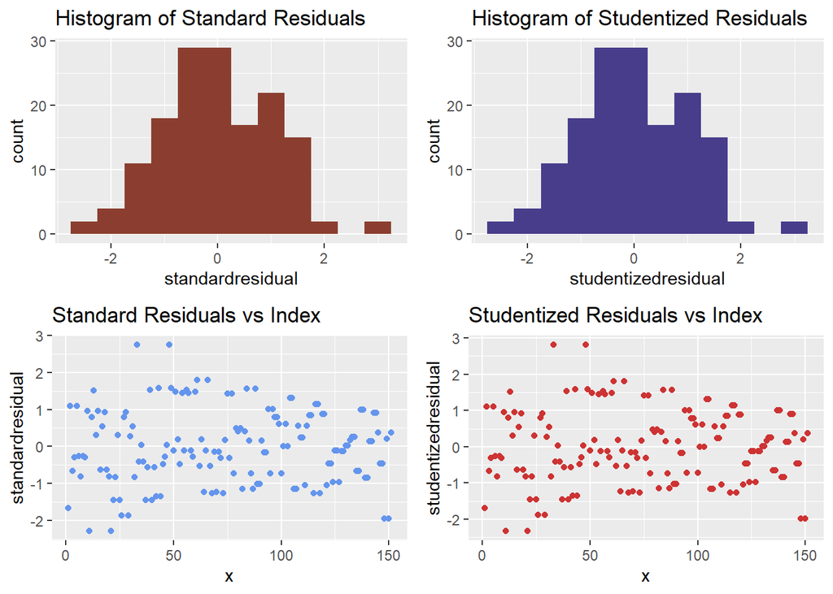

```r
# Calculate standard residuals from the best model
standardresidual <- rstandard(best_model)
dfstandardresidual <- data.frame(standardresidual)

# Calculate studentized residuals from the best model
studentizedresidual <- studres(best_model)
dfstudentizedresidual <- data.frame(studentizedresidual)

# Add an index column for plotting
dfstandardresidual$x <- seq(1:nrow(dfstandardresidual))
dfstudentizedresidual$x <- seq(1:nrow(dfstudentizedresidual))

# Plot a histogram of standard residuals
plot1 <- ggplot(dfstandardresidual, aes(x = standardresidual)) +
  geom_histogram(binwidth = 0.5, fill = "coral4") +
  ggtitle("Histogram of Standard Residuals")

# Plot a histogram of studentized residuals
plot2 <- ggplot(dfstudentizedresidual, aes(x = studentizedresidual)) +
  geom_histogram(binwidth = 0.5, fill = "darkslateblue") +
  ggtitle("Histogram of Studentized Residuals")

# Scatter plot of standard residuals against their index
plot3 <- ggplot(dfstandardresidual, aes(x = x, y = standardresidual)) +
  geom_point(color = "cornflowerblue") +
  ggtitle("Standard Residuals vs Index")

# Scatter plot of studentized residuals against their index
plot4 <- ggplot(dfstudentizedresidual, aes(x = x, y = studentizedresidual)) +
  geom_point(color = "brown3") +
  ggtitle("Studentized Residuals vs Index")

# Arrange the plots in a 2x2 grid
grid.arrange(plot1, plot2, plot3, plot4, nrow = 2, ncol = 2)
```

**Interpretation:**

Standardized residuals standardize the residuals by dividing each residual by its estimated standard deviation that is normally distributed and adjusting its standard deviation to 1. Standardized residuals close to 0 indicate that the observed values are close to what is predicted by the model, while values far from 0 indicate potential outliers or points where the model may not fit well.

While studentized residuals standardize the residual by dividing each residual by an estimate of its standard deviation that takes into account the influence (leverage) of each observation on the model fit.

They are typically used for assessing the overall fit of the model and identifying outliers.

It may be inferred that the **residuals are normally distributed in general** from the histograms of the studentized and standardised residuals, which exhibit normal distribution. This is a positive indicator as it indicates that one of the **fundamental requirements of linear regression (normally distributed residuals) has been met**. Model 6 appears to be accurately representing the relationship between the predictors and the response variable, based on the residuals’ normality.

However, some residuals on the right-hand side of the histogram seem to be the outliers as they separate distinctly from the other values. The presence of outliers is further supported by the scatterplots of the standardised and studentized residuals, which reveal that most dots fall between the intervals of -2 and 2, with only 4 dots falling outside of it.

# Diagnostic Plots

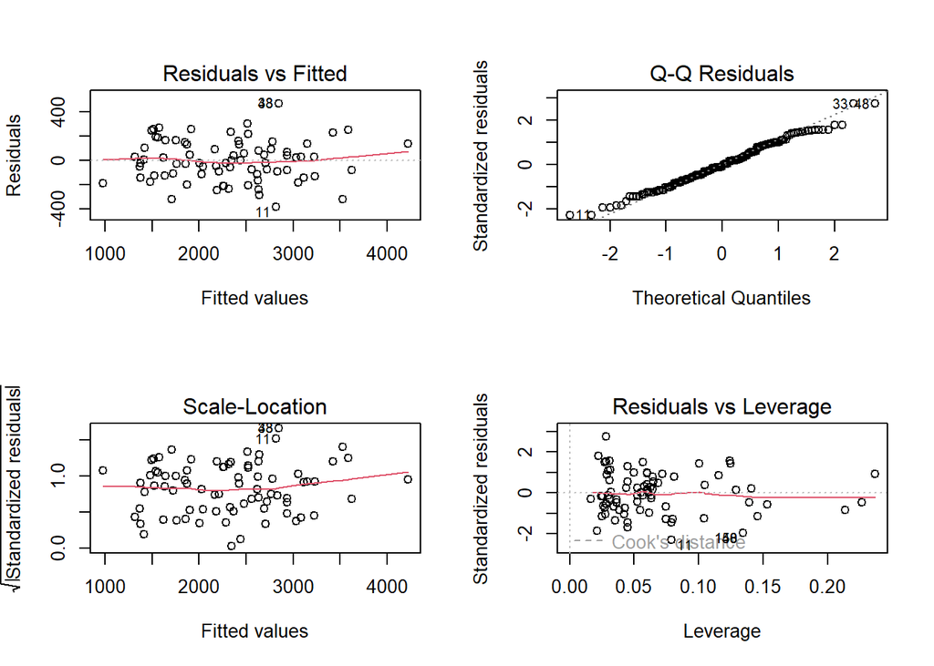

```r
# Set up a 2x2 plotting area and create diagnostic plots for the best_model
par(mfrow = c(2, 2))
plot(best_model)
```

Four diagnostic plots are generated for model 6 to assess the quality and assumptions of the regression model.

**Residuals vs Fitted:**

- This graph checks the linearity assumption and identifies non-linear patterns. There appears to be a **slight trend in the residuals**, suggesting potential non-linearity or that some predictor variables might be missing from the model.

**Normal Q-Q:**

- This graph checks if the residuals are normally distributed. In the plot, the points mostly lie along the 45-degree line, suggesting the residuals are **approximately normally distributed**, although there are **some deviations at the tails**.

**Scale-Location (Spread-Location):**

- This graph checks the homoscedasticity assumption, that is the constant variance of residuals. In the plot, the **residuals are spread fairly constant across the fitted values**, the red line is also relatively horizontal, though there is some indication of increasing variance with higher fitted values.

**Residuals vs Leverage:**

- This graph identifies influential data points that have a high leverage or high residual. In the plot, **most points lie within Cook’s distance lines**, but there are some potentially influential points, but they do not have an excessive influence on the model, none seem overly problematic.

# Confidence level

The 95% confidence intervals for each coefficient in model 6 is calculated.

```r
# Calculate confidence intervals for the coefficients of the best_model
confint(best_model)
```

```
##                     2.5 %       97.5 %
## (Intercept) 1713.80433685 2454.3359933
## ScreenSize  -165.17265585  -71.0126140
## PPI            0.77321335    1.5421448
## CPU_core      32.10722030   71.2930868
## CPU_freq      40.83117854  221.0713082
## InternalMem    2.77434246    7.2054228
## RAM           49.86232835  150.1968406
## FrontCam      -2.13713068   16.8958046
## Battery        0.08504466    0.1882895
## Thickness   -120.72546288  -70.3479349
```

The **intercept term is statistically significant**, suggesting that the baseline price of a mobile phone (when all other variables are zero) falls within this range. **For the other variables excluding front camera, the absence of zero within these intervals indicates the statistical significance of the corresponding coefficients.** The coefficient of screen size and thickness falls within the negative range, indicating these two variables are negatively correlated to the mobile phone price. On the other hand, the coefficient of the remaining variables falls within the positive range, indicating the variables are positively correlated to the mobile phone price. **As the confidence interval of the front camera ranges from -2.14 to 16.90, which includes zero, it suggests that the effect of the front camera on price is not statistically significant at the 95% confidence level.**

# ANOVA

```r
# Perform ANOVA analysis on the best_model to assess the significance of predictors
anova(best_model)
```

```
## Analysis of Variance Table
##
## Response: Price
##              Df   Sum Sq  Mean Sq   F value    Pr(>F)
## ScreenSize    1  2399174  2399174   80.2420 1.772e-15 ***
## PPI           1 43852457 43852457 1466.6751 < 2.2e-16 ***
## CPU_core      1  4543260  4543260  151.9524 < 2.2e-16 ***
## CPU_freq      1   379754   379754   12.7011 0.0004992 ***
## InternalMem   1 11605706 11605706  388.1607 < 2.2e-16 ***
## RAM           1  1088612  1088612   36.4094 1.338e-08 ***
## FrontCam      1    64000    64000    2.1405 0.1456790
## Battery       1   249869   249869    8.3570 0.0044507 **
## Thickness     1  1681009  1681009   56.2225 6.566e-12 ***
## Residuals   141  4215791    29899
## ---
## Signif. codes:  0 '***' 0.001 '**' 0.01 '*' 0.05 '.' 0.1 ' ' 1
```

Analysis of variance (ANOVA) is performed on model 6 to assess the significance of each predictor in the regression model. **Overall, the variables in the model are statistically significant predictors of mobile phone price, with the exception of the front camera, which is not significant**. However, the significance of the variables can be further interpreted by assessing the Pr(>F) values. Pr(>F) values less than 0.05 are considered statistically significant at the 5% significance level. ScreenSize, PPI, CPU_core, InternalMem, RAM, Thickness, CPU_freq and Battery all have Pr(>F) values less than 0.05, indicating they are highly significant predictors. On the other hand, **FrontCam has a Pr(>F) value approximately 0.15, indicating that the front camera does not significantly affect phone pricing at the 5% significance level.**

# Conclusion

**Topic Overview and Data Description**

The primary focus of this study is to explore the mobile phone market, particularly how various features influence the pricing of mobile phones. We utilised a comprehensive dataset from Kaggle, which includes diverse specifications such as weight, thickness, battery capacity, screen resolution, pixels per inch (PPI), camera features, CPU specifications, internal memory, and RAM. These variables form the backbone of our analysis, helping us understand which factors consumers value most when it comes to mobile phone pricing.

**Model Setup and Analysis**

To effectively address the project’s objectives, multiple regression models were designed to identify the variables that most significantly impact mobile phone pricing. In total, we constructed six distinct models, each incorporating various combinations of the aforementioned features. These models were rigorously analysed to discern how well they explained the variability in mobile phone prices.

**Model Selection Key Points and Best Model Determination**

The selection of the best model was based on several statistical criteria:

- **R-Squared and Adjusted R-Squared:** These metrics showed that Models 5 and 6 closely followed the Full Model in terms of explanatory power, indicating robust model performance.
- **Mallows’ Cp:** Among the models, Model 6 demonstrated a lower Cp value, suggesting it has a good balance between accuracy and simplicity.
- **Number of Predictors and AICc:** Model 6, with fewer predictors and the lowest AICc, provided an optimal balance, reducing complexity while maintaining a high level of explanatory power.

Based on these criteria, Model 6 emerged as the best model. It effectively captured the relationship between mobile phone features and pricing with sufficient complexity to avoid overfitting.

**Significant Predictors and Their Implications**

The best model highlighted several significant predictors of mobile phone pricing as they directly relate to the performance and user experience of a mobile phone. According to Maesya et al. (2023), RAM, number of CPU cores, CPU frequency, PPI, internal memory and battery have significantly positive impacts on the price of mobile phones, which also has been evident by several other studies (Listianingrum et al., 2021; Ahmad et al., 2019). The positive relationship between these variables and price indicates that consumers are willing to pay more for higher performance and better display quality. Moreover, it is also revealed that screen size and thickness significantly negatively impacts mobile prices. On the other hand, studies have also indicated that although camera quality can affect consumers’ decisions, the front camera in particular does not have as much of an impact on the final price as other features do (Maesya et al., 2023; Listianingrum et al., 2021).

**Implications for Mobile Phone Companies**

The findings from this study provide actionable insights for mobile phone companies. By understanding the features that significantly affect pricing, companies can strategically design their products to align with consumer preferences. For instance, investing in advanced display technology and higher memory capacities can justify higher price points and cater to consumer demand for more powerful devices. Moreover, the preference for sleeker designs, as indicated by the negative correlation with thickness, suggests that slimmer phones could be marketed as premium offerings.

In conclusion, this analysis not only aids in setting competitive pricing strategies but also guides product development by highlighting the features that are most valued by consumers in different market segments. By tailoring products according to these insights, mobile phone companies can better meet consumer expectations and enhance their market position and also attain a goal of maximising profit.